# TURNT-16S exploration

2022-09-07

# Overview

Pairs of Turbinaria individuals were placed in clear aquaria on a water table.

There were three treatments:

C = **control**, collected at ‘normal’ reef site, no nutrient addition

N = **nutrient**, collected at ‘normal’ reef site site, osmocote added during experiment

R = **recharge**, collected at long-term osmocote addition site, osmocote added during experiment

B = **blank**, emtpy aquaria containing filtered seawater water that were left out on water table during treatment

There were four data points collected:

**exudation_1** = initial exudation after bringing Turbinaria in from the collection site (post 24hr acclimation period)

**exudation_2** = exudation after 4 days of treatment

**remin_T0** = exudation 2 products pooled by treatment, mixed with reef water, and subsampled.

**remin_TF** = remaining compounds after 24hr remineralization by microbes

Timeline: Collection ->

```
Acclimation (24hr) ->

  Exudation 1 (~10 hr) ->

   Treatment (4 days) ->

    Exudation 2 (~10 hr) ->

      Pool exudates by treatment ->

        T0 remin sampling ->

         Remineralization (24 hr) ->

          TF remin sampling
```

Purpose of this document:

```r
library(data.table)
library(ggplot2)
library(vegan)
set.seed(2020)

otu_file = "../data/16S/16S-pipeline_outputs/Results/main/abundance_table_100.csv"
unifrac_file = "../data/16S/16S-pipeline_outputs/Results/postprocessing/unifrac/unifrac_weighted_100.csv"
run_map_file = "../data/16S/2022-0018_16S amplicons.csv"
sample_meta_file = "../data/sample_data/TURNT_sample_sheet - DNA_tubes.csv"

otu_raw = fread(otu_file, sep = ",")
run_map = fread(run_map_file)
sample_meta = fread(sample_meta_file)

unifrac = read.csv(unifrac_file)

TURNT_samples = sample_meta$bead_tube

turnt_clrs = c(
  control = "#73d9f0",
  nutrient = "#f7b301",
  recharge = "#eb773e",
  blank = "gray",
  exudation_1 = "yellow2",
  exudation_2 = "yellow4",
  remin_T0 = "thistle1",
  remin_TF = "thistle3"
  )

theme_set(theme_minimal())
```

```r
# organizing data
# separate otu taxonomy from counts
tax_cols = c( "repSeqName", "repSeq", "OTUConTaxonomy")

otu = otu_raw[ , .SD, .SDcols = !tax_cols]


tax_raw = otu_raw[ , .SD, .SDcols = c("OTUNumber",tax_cols)]
tax = fread(text = tax_raw$OTUConTaxonomy, sep = ";")
names(tax) = c(
                "kingdom",
                "phylum",
                "class",
                "order",
                "family",
                "genus",
                "species"
)
tax[ , species := NULL]
tax[ , OTUNumber := tax_raw$OTUNumber]

# drop non-TURNT samples
keep_cols = names(otu)[names(otu) %in% TURNT_samples]
otu = otu[ , .SD, .SDcols = c("OTUNumber",keep_cols)]

# drop empty otus
drop_otus = rowSums(otu[ , -1]) > 0
otu = otu[drop_otus,]

# transpose otu table so samples are rows
t_otu = transpose(otu, keep.names = "bead_tube", make.names = "OTUNumber")


# clean unifrac distances and store as matrix
row.names(unifrac) = unifrac$X
unifrac = unifrac[ , colnames(unifrac) != "X"]
colnames(unifrac) = gsub("X(.+)", "\\1", colnames(unifrac))

all_d = unifrac[row.names(unifrac) %in% TURNT_samples,
                  colnames(unifrac) %in% TURNT_samples]



# merge sample meta and run map
setnames(run_map, "Sample Name", "bead_tube")
run_map[ , bead_tube := sub(" ","_", bead_tube)]

all_meta = merge(sample_meta, run_map, by = "bead_tube", all.x = T)
```

```r
# QC the run
# check which samples made it through the pipeline
meta = all_meta[bead_tube %in% row.names(all_d)]
bad_meta = all_meta[!(bead_tube %in% meta$bead_tube)]

# bad meta == all the tissue samples
```

# Ordination

To start, we’ll run some NMDS ordinations. First, ordinating all samples together, then by each stage of the experiment. I’m using both unifrac distances (generated for all samples by the metaflowmics pipeline) and bray curtis distances (generated by vegdist for each data subset).

```r
# ordination function
ord_uni = function(dist_mat){
  ord = metaMDS(comm = as.dist(dist_mat))
  out = list(points = as.data.table(ord$points, keep.rownames = "bead_tube"),
             stress = round(ord$stress, 3))
  return(out)
}

ord_bray = function(otu_dt){

  otu_mat = as.matrix(otu_dt[ , .SD, .SDcols = !"bead_tube"])
  row.names(otu_mat) = otu_dt$bead_tube

  ord = metaMDS(comm = otu_mat, distance = "bray")
  out = list(points = as.data.table(ord$points, keep.rownames = "bead_tube"),
             stress = round(ord$stress, 3))
  return(out)
}

plot_ord = function(ord_out, p_title= NULL, color_var){
 points = ord_out$points
 ord_meta = merge(points, meta, by = "bead_tube")

 p_colors = turnt_clrs[names(turnt_clrs) %in% unique(meta[[color_var]])]


 ggplot(ord_meta, aes_string(x = "MDS1", y = "MDS2", color = color_var))+
   geom_point(size = 3)+
   scale_color_manual(values = p_colors)+
   labs(title = p_title,
        caption = paste("Stress =", ord_out$stress))
}
```

## All samples

Ordinating all the samples together, we see clear separation between the different stages of the experiment. At this level, it’s hard to see differences between the treatments within each stage.

We expect microbial communities to vary quite a bit between experimental stages. Exudations were performed on pairs of turbinaria prior to nutrient treatment and post nutrient treatment. Remineralizations were pseudoreplicates of the same microbial community exposed to different algal exudates. I’d guess remin samples would be much more tightly clustered than the exudation samples and pretty distinct, compositionally. And that’s what we see.

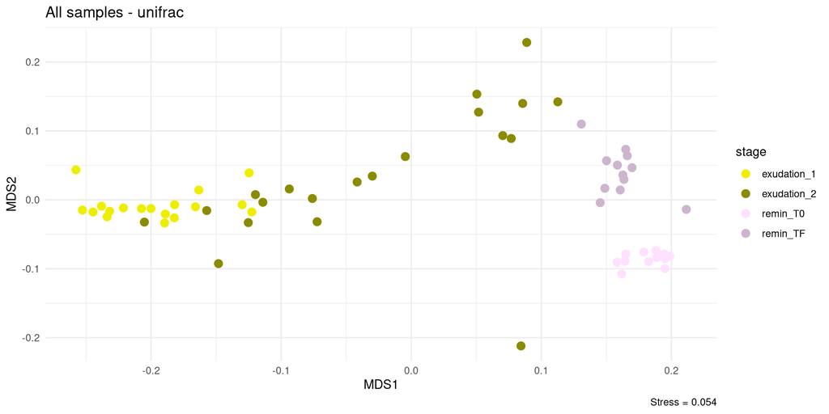

```r
plot_ord(all_ord_uni,
         "All samples - unifrac",
         color_var = "stage")
```

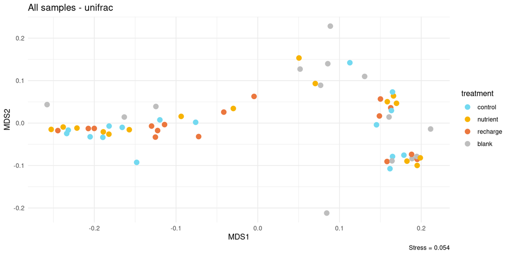

```r
plot_ord(all_ord_uni,
         "All samples - unifrac",
         color_var = "treatment")
```

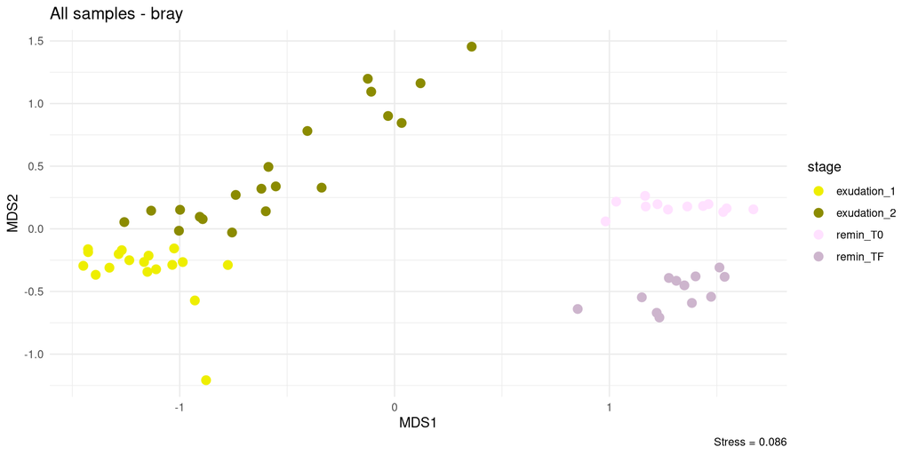

```r
plot_ord(all_ord_bray,
         "All samples - bray",
         color_var = "stage")
```

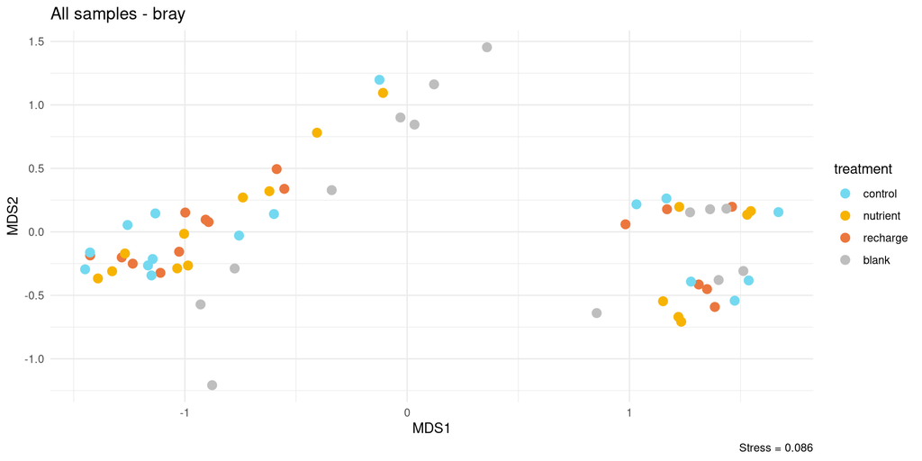

```r
plot_ord(all_ord_bray,
         "All samples - bray",
         color_var = "treatment")
```

## Exudations

The ‘exudation’ microbes are whatever microbes managed to sneak into our filtered water during the two 10 hr exudations. We definitely expect to see a difference between the ‘blanks’ and all other samples. Blanks are just empty aquaria with filtered water. They shouldn’t have a lot going on microbially.

Prior to **exudation 1**, all of the turbinaria individuals were acclimating to captivity in the same big blue tub. We rinsed each individual with filtered water prior to exudation, but I’d still expect some random variation in the microbes that were present on each individual. Microbes splashing or falling into the aquaria are another source of random variation.

Prior to **exudation 2**, turbinaria had been marinating in 3 separate flow through containers for 4 days with different nutrient treatments. We might see some separation by treatment in the exudation 2 microbes. If microbes were carried on the surface of the turbinaria into the exudation aquaria, then maybe samples from the same treatment (and thus the same treatment aquarium) would be more similar. Could also be that the differences in exudates between treatments are strong enough to drive a shift in random microbes during the exudation period. Not sure if any of this is super informative.

### Exudation 1

As expected real samples cluster together, blanks separate out. Differences between samples are random at this stage.

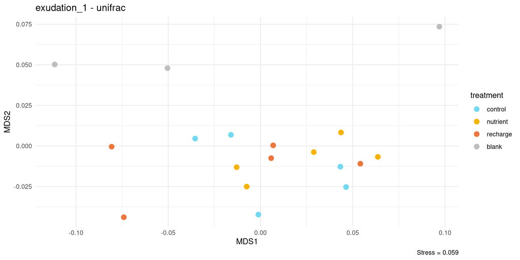

```r
all_ords$exudation_1$uni_plot
```

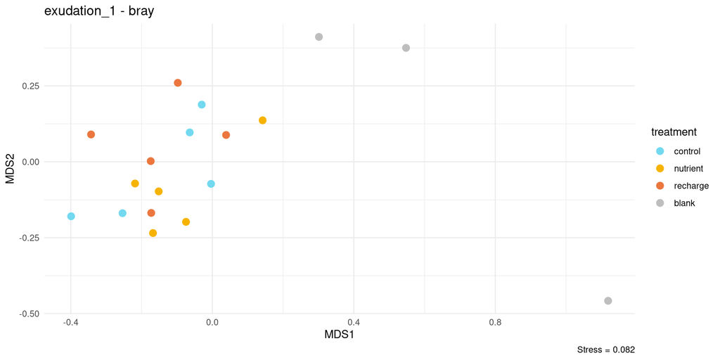

```r
all_ords$exudation_1$bray_plot
```

### Exudation 2

This looks kind of messy. Blanks mostly separate out, but a control sample and two nutrient samples group with the blanks. One blank sample looks like an outlier. Should probably drop that and re-ordinate. Even if I do that, I don’t see any clear treatment level patterns.

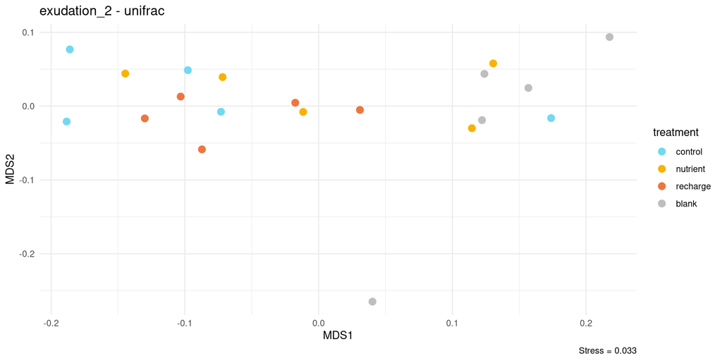

```r
all_ords$exudation_2$uni_plot
```

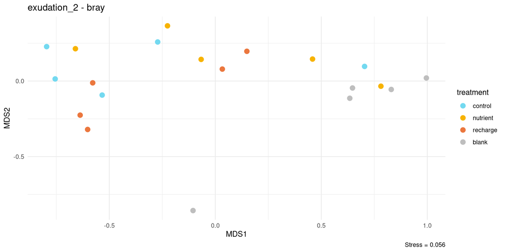

```r
all_ords$exudation_2$bray_plot
```

## Remineralizations

Microbial data from the remineralizations should be interesting. This is a stage where we expect to see shifts in the microbial community. Remin T0 starts with the same microbial community, so all samples should be very similar.

### Remin T0

This is the begining of the remineralization stage of the experiment.

Initial observation: control sample 39_T is a clear outlier here. Not sure what’s going on in that sample, but it throws off the ordination. I dropped 39_T and re-ran

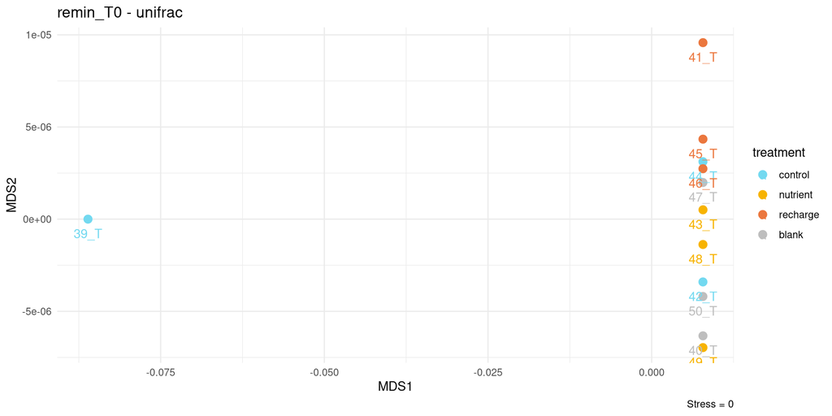

```r
all_ords$remin_T0$uni_plot + geom_text(aes(label = bead_tube), vjust = 2)
```

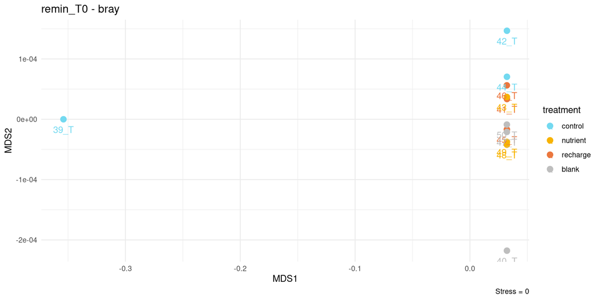

```r
all_ords$remin_T0$bray_plot+ geom_text(aes(label = bead_tube), vjust = 2)
```

Here are the ordinations again with the outlier removed. Looks good to me. They aren’t super different from each other and they are sort of mixed together. Given that they all have the same microbial community spiked in, that seems appropriate. Samples still kind of group together by treatment, but that’s not totally unexpected. They are pseudoreplicates after all.

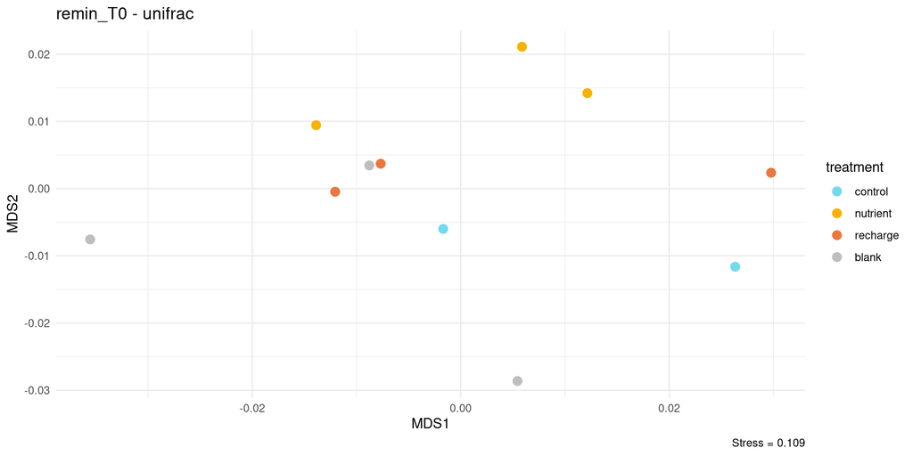

```r
clean_remin_T0$uni_plot
```

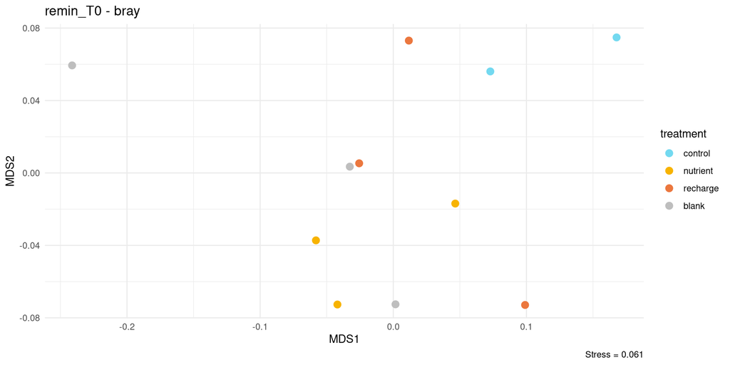

```r
clean_remin_T0$bray_plot
```

## Remin TF

This is where we want to see some sort of intelligble pattern separating the treatments. The wild microbial community was given 4 types of food: - control exudates (no nutrient addition) - recharge exudates (long term nutrient addition) - nutrient exudates (short term nutrient addition) - blank (just water, no food)

Do the different food sources shift the microbial community in a consistent way or does it not matter?

Looks like yes. Adding turbinaria exudates caused microbial communities to shift away from the blanks. The nutrient treatment was the most different from the blanks, followed by recharge, with controls being the least different and most variable. All three samples from the nutrient treatment are highly similar, which is cool. Looks like they all ended up with the same community, which supports the idea that the exudates were actually driving community composition. I think this tracks with the flow cytometry data, too (but that’s for later).

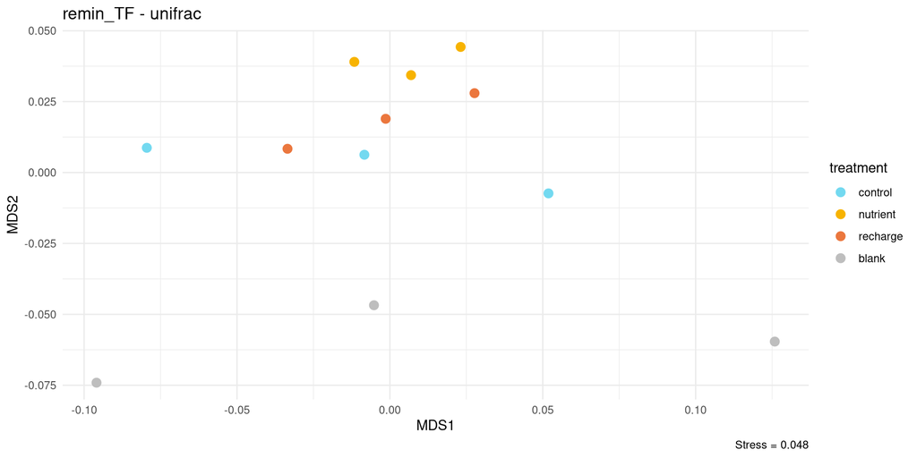

```r
all_ords$remin_TF$uni_plot
```

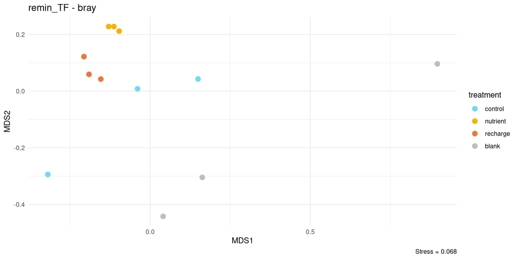

```r
all_ords$remin_TF$bray_plot
```

### Remin Track Changes

In other words, 24 hours in a bottle has a strong effect on the microbial community. Adding turbinaria exudates further shifts the community. Adding exudates from turbinaria that were fed nutrients shifts the community even further. Adding turbinaria exudates from individuals that received a sudden spike in nutrients causes the strongest shift of all.

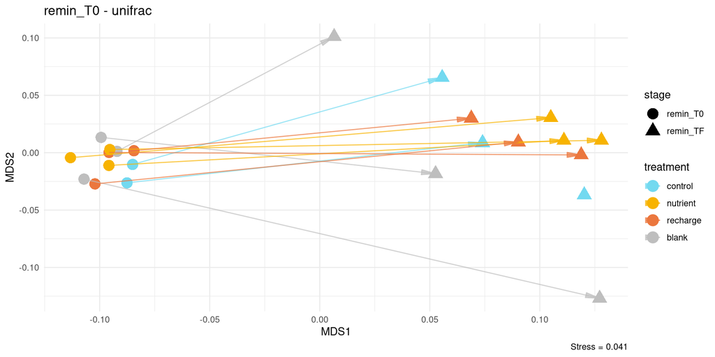

```r
remins_ord$uni_plot + geom_point(aes(shape = stage), size = 5)+
                                   geom_line(aes(group = rep), arrow = arrow(angle = 10,
                                                                             length = unit(0.2, "inches"),
                                                                             type = "closed"),
                                             alpha = 0.7)
```

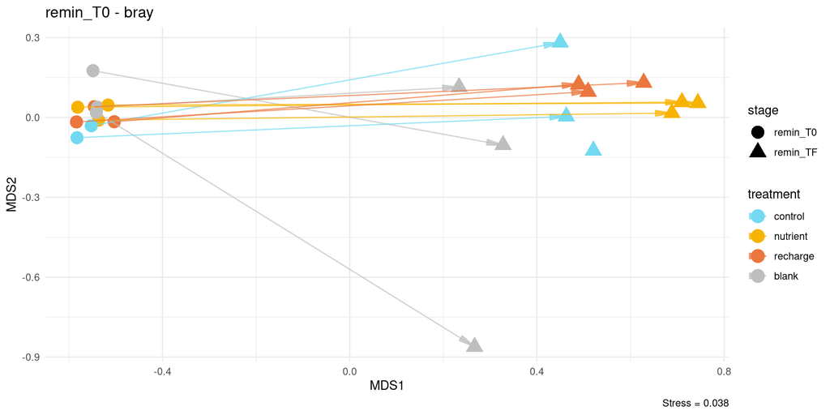

```r
remins_ord$bray_plot + geom_point(aes(shape = stage), size = 5)+
                                   geom_line(aes(group = rep), arrow = arrow(angle = 10,
                                                                             length = unit(0.2, "inches"),
                                                                             type = "closed"),
                                             alpha = 0.7)
```

# Heatmaps

This is a work in progress. I’d like to see what microbes are different in the remin TF samples. This is just a placeholder graphic, for now. I’ll probably sum relative abundance by family.

```r
# function to sum by family

sum_by_tax = function(otus,
                      tax_table,
                      tax_level = "family",
                      cutoff = 40){

  otu_key = merge(otus,
                    tax_table[, .SD, .SDcols = c(tax_level, "OTUNumber")],
                    by = "OTUNumber",
                    all.x = T)
  otu_key[, OTUNumber := NULL]

  # sum by tax level
  otu_sum = otu_key[, lapply(.SD, sum), by = tax_level]

  # order by most abundant taxa
  otu_sum[ , tax_sums := rowSums(otu_sum[ , .SD, .SDcols = !tax_level])]
  otu_sum = otu_sum[tax_sums > 0]
  otu_sum = otu_sum[order(tax_sums, decreasing = T)]
  otu_sum[ , tax_sums := NULL]

  return(otu_sum)
}

# generate heatmap
make_heatmap = function(otu_dt, id_col, col_labs){
 otu_mat = as.matrix(otu_dt[ , .SD, .SDcols = !id_col])

 heatmap(otu_mat, labCol = col_labs)
}
```

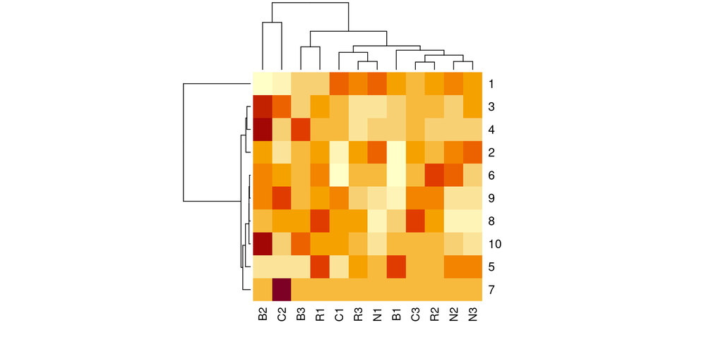

```r
# make a heatmap of the remin TF taxa

tf_otu = otu[, .SD, .SDcols = c("OTUNumber", meta[stage == "remin_TF", bead_tube])]

tf_fam_sum = sum_by_tax(tf_otu, tax, tax_level = "family")

tf_labs = meta[match(colnames(tf_fam_sum)[-1],bead_tube), rep]

make_heatmap(tf_fam_sum[1:10], "family", tf_labs)
```